# Tutorial Part I - Quick introduction to R

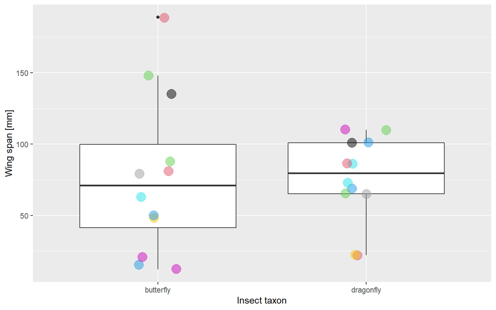

```r
ggplot(mydata, aes(insect, wingspan)) +
  geom_boxplot() +
  geom_jitter(color = wind_speed,width = .1, alpha = .5,size=5) +
  labs(x = "Insect taxon", y = "Wing span [mm]")
```

An informative alternative are violin-plots:

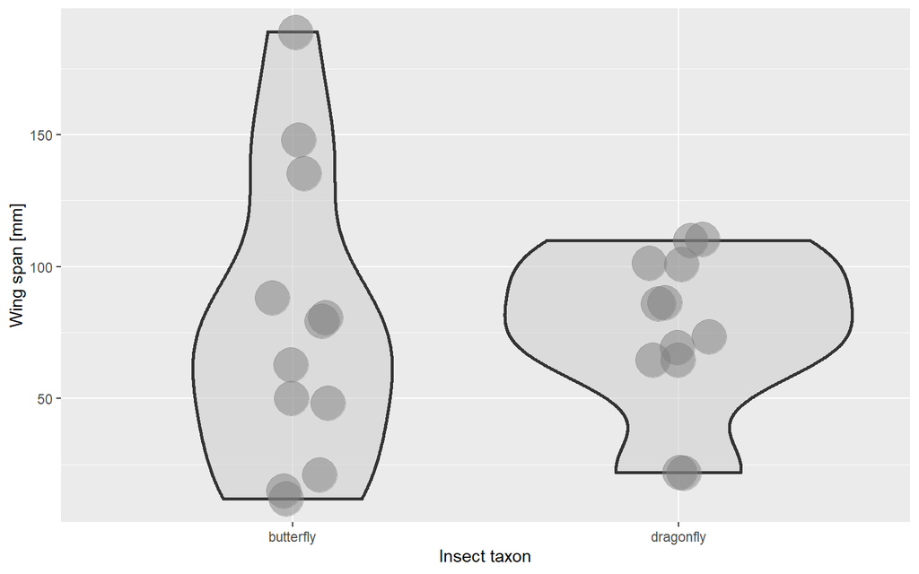

```r
ggplot(mydata, aes(insect, wingspan)) +
  geom_violin(fill = "gray80", size = 1, alpha = .5) +
  geom_jitter(color = 'grey50',width = .1, alpha = .5, size=10) +
  labs(x = "Insect taxon", y = "Wing span [mm]")
```

Or another beautiful possibility, the ridge plot. Please note: this is a density plot, forcing beginning and end through zero. But: we never measured wing spans of zero!

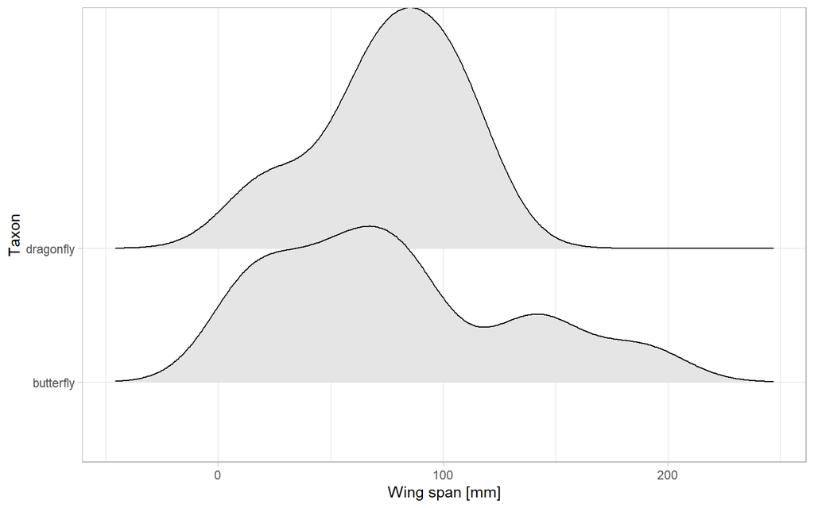

```r
library(ggridges) #install package
ggplot(mydata, aes(wingspan, factor(insect))) +
   geom_density_ridges(fill = "gray90") +
   labs(x = "Wing span [mm]", y = "Taxon") +
   theme_light()
```

The following is playing around with images

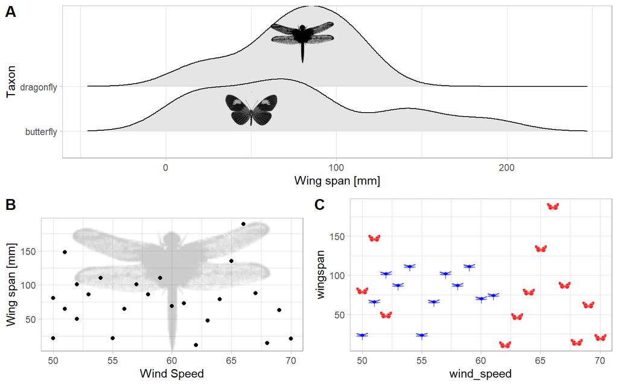

```r
library(rphylopic) # install first
library(ggpubr)    # for arranging the plots

#import phylopic (go to phylopic.org -> browse image -> click on image to get url)
drfly <- image_data("2894776f-a2cf-4475-b13d-6d8ea1607ea4", size = 128)[[1]]
bufly <- image_data("ef0f4ab5-9714-45dc-8760-57e9080f941e", size = 128)[[1]]

p1 <- ggplot(data=mydata) +
             geom_point(aes(x=wind_speed, y =wingspan)) +
             theme_light() +
             labs(x= 'Wind Speed', y= 'Wing span [mm]', title='',size= 15) +
             add_phylopic(img=drfly)

###
p2 <- ggplot(data=mydata,aes(x=wind_speed, y =wingspan)) +
                theme_light() +
                geom_point(color = rgb(0,0,0,0))

sub_drag <- subset(mydata, insect == 'dragonfly')
sub_butt <- subset(mydata, insect == 'butterfly')

for (i in 1:nrow(sub_drag)) {
  p2 <- p2 + add_phylopic(drfly, 1,
                           sub_drag$wind_speed[i],
                           sub_drag$wingspan[i],10,'blue')}
for (j in 1:nrow(sub_butt)) {
  p2 <- p2 + add_phylopic(bufly, 1,
                           sub_butt$wind_speed[j],
                           sub_butt$wingspan[j],10,'red')}

###
p3 <- ggplot(mydata, aes(wingspan, factor(insect))) +
                geom_density_ridges(fill = "gray90") +
                labs(x = "Wing span [mm]", y = "Taxon") +
                theme_light() +
                add_phylopic(img=bufly, alpha=1,
                             x = 50, y = 1.5, ysize=20) +
                add_phylopic(img=drfly, alpha=1,
                             x = 80, y = 3, ysize=25)

# TRY:
# ggarrange(p1, p2, p3,ncol = 2, nrow = 2)

ggarrange(
  p3,                # First row with ridge plot
  # Second row with other plots
  ggarrange(p1, p2, ncol = 2, labels = c("B", "C")),
  nrow = 2,
  labels = "A"       # Label of the line plot
  ) # %>% ggexport(filename = "multifigure.png")# and save the plot
```

Happy with the plot? Then save it:

```r
myridgeplot <- ggplot(mydata, aes(wingspan, factor(insect))) +
   geom_density_ridges(fill = "gray90") +
   labs(x = "Wing span [mm]", y = "Taxon") +
   theme_light()

myfilename <- "ridges.pdf"

ggsave(myridgeplot, file=myfilename, width=4, height=4)
```

And find more inspiration here: https://www.r-graph-gallery.com/

# Advanced - Programming with R (shortly)

This is very helpful for understanding your own data (i.e. simulate data where you know exactly what happens and where you know what should come out) or when you have repeated operations to do.

## Simulate your own data

R has a lot of distribution functions:  
https://stat.ethz.ch/R-manual/R-devel/library/stats/html/Distributions.html

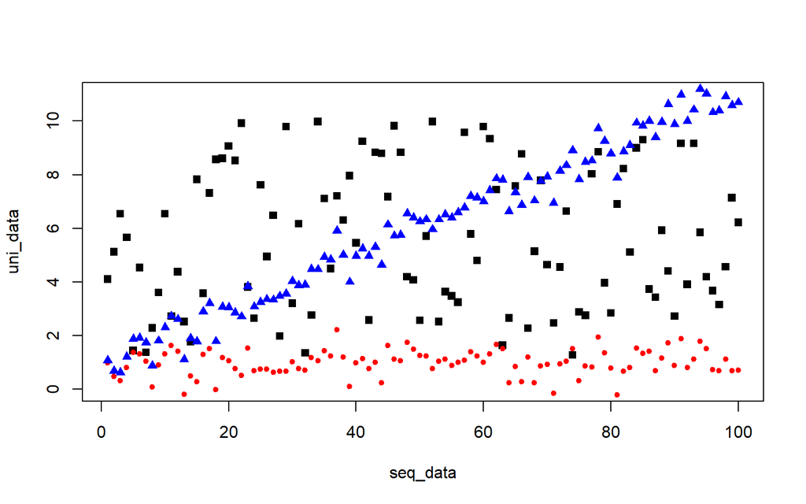

```r
seq_data  <- seq(from = 1, to = 100, by = 1)     # create the x-axis
uni_data  <- runif(n = 100, min = 1, max = 10)   # create random uniform data between 1-10
norm_data <- rnorm(n = 100, mean = 1, sd = 0.5)  # create normally distributed data

#simulate trend = y-axis: intercept with noise + (estimate * variable)
trend_data <-  norm_data + (0.1 * seq_data)

par(mfrow=c(1,1))
plot(x = seq_data, y = uni_data, pch = 15, ylim = c(0,11)) #uniform -> runif
points(x = norm_data, pch = 20, col = 'red') #Gaussian
points(x = trend_data, pch = 17, col = 'blue') #trend
```

### Just for fun: some stats….

```r
my.lm <- lm(formula = trend_data ~ seq_data)
#abline(my.lm)
summary(object = my.lm) #surprise.... the intercept is ~1 and estimate ~ 0.1
```

```
##
## Call:
## lm(formula = trend_data ~ seq_data)
##
## Residuals:
##      Min       1Q   Median       3Q      Max
## -1.25158 -0.26004  0.02803  0.31509  1.26590
##
## Coefficients:
##             Estimate Std. Error t value Pr(>|t|)
## (Intercept) 0.875216   0.096677   9.053 1.37e-14 ***
## seq_data    0.102090   0.001662  61.425  < 2e-16 ***
## ---
## Signif. codes:  0 '***' 0.001 '**' 0.01 '*' 0.05 '.' 0.1 ' ' 1
##
## Residual standard error: 0.4798 on 98 degrees of freedom
## Multiple R-squared:  0.9747, Adjusted R-squared:  0.9744
## F-statistic:  3773 on 1 and 98 DF,  p-value: < 2.2e-16
```

## The *for* loop

saves a lot of time to automate operations, ie. do the same operation on 1000 datasets

```r
#- for repetitive operations
#- *i* is used as variable that is incremented
for(i in 1:4)
{ #begin
  print(x = i)
  if (i == 4) print (x = 'end of lop')
} # end
```

```
## [1] 1
## [1] 2
## [1] 3
## [1] 4
## [1] "end of lop"
```

```r
?'for'
#other useful control flow constructs are: *while*, *repeat*, *if*
```

## Writing your own function

Also for repetitive actions and often used operations. the basic syntax is:  
function(*argument*){1 + 1 - *argument*}  
The function needs an argument, like e.g. a vector with numbers in the case of the function mean(), and in the {} some operations are done with the argument.

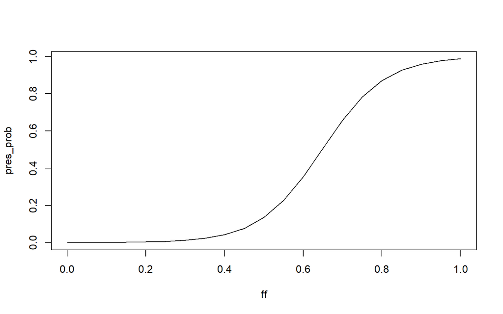

```r
f_logit <- function(a) {-8.13 + (12.55 * a)}
f_prob <- function(x) {1/ (1 + exp(x = -x))} # inverse logit

# ff = e.g. frequency of forest in a cell
ff <- seq(from = 0, to = 1 ,by = 0.05)

the_logit  <- f_logit(a = ff)
pres_prob  <- f_prob(x = the_logit)

#pres_prob
plot(x = ff,y = pres_prob, type = 'l')
```

### Logistic regression and inverse logit

Similar to example above

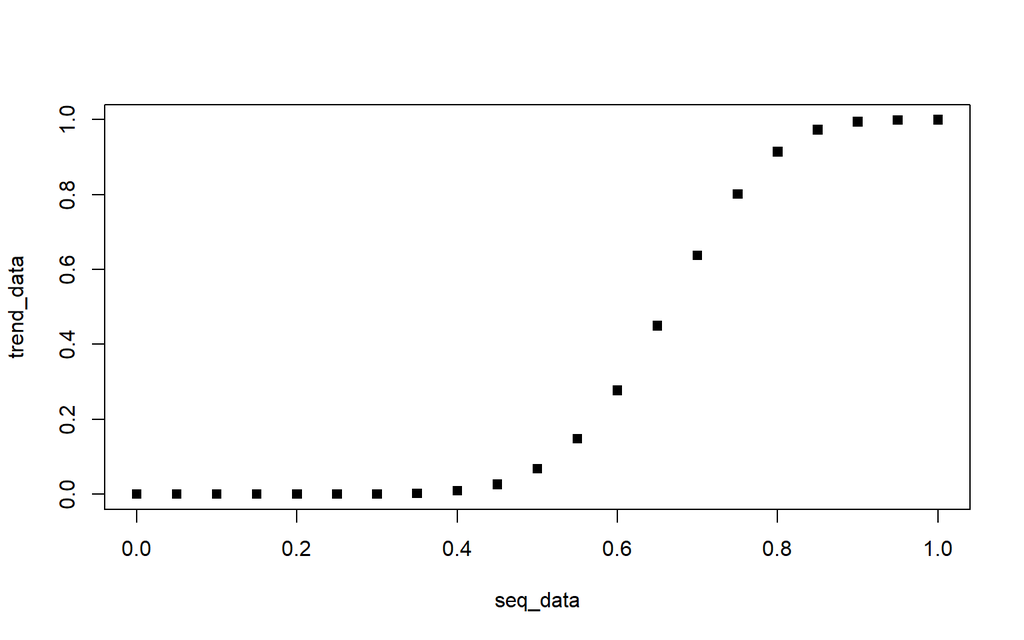

```r
# define functions at the beginning of a script:
f_logit <- function(var_value, intcpt, slp) {intcpt + (slp * var_value)}
f_prob  <- function(x) {1 / (1 + exp(x = -x))} #inverse logit

# simulate trend or load data:
seq_data  <- seq(from = 0, to = 1, by=0.05)
trend_data <- pbinom(q = 1:length(seq_data), size = length(seq_data), prob = 0.7)
plot(x = seq_data, y = trend_data, pch = 15)
```

```r
# analyse data
my.lm <- glm(formula = trend_data ~ seq_data, family = 'binomial', na.action = na.omit)
summary(my.lm)
```

```
##
## Call:
## glm(formula = trend_data ~ seq_data, family = "binomial", na.action = na.omit)
##
## Deviance Residuals:
##      Min        1Q    Median        3Q       Max
## -0.06484  -0.02327  -0.01079   0.03845   0.09538
##
## Coefficients:
##             Estimate Std. Error z value Pr(>|z|)
## (Intercept)  -11.467      6.046  -1.897   0.0579 .
## seq_data      17.372      9.060   1.917   0.0552 .
## ---
## Signif. codes:  0 '***' 0.001 '**' 0.01 '*' 0.05 '.' 0.1 ' ' 1
##
## (Dispersion parameter for binomial family taken to be 1)
##
##     Null deviance: 19.633032  on 20  degrees of freedom
## Residual deviance:  0.044444  on 19  degrees of freedom
## AIC: 7.7883
##
## Number of Fisher Scoring iterations: 8
```

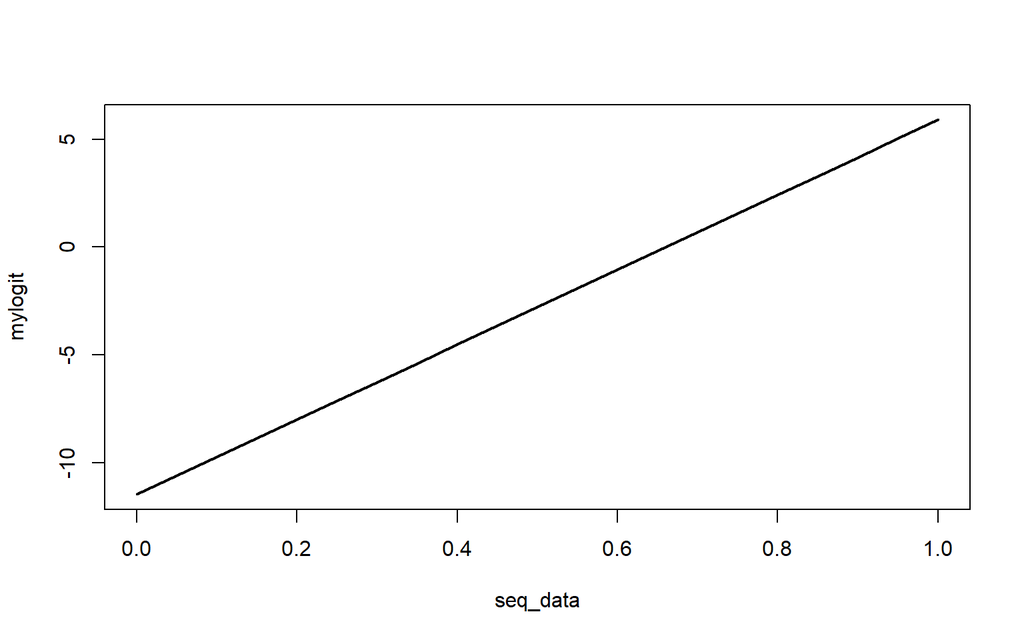

```r
# store the output; access my.lm object via:
#str(my.lm)
myintercept <- my.lm$coefficients[[1]]
myslope     <- my.lm$coefficients[[2]]

# predict it for a certain range of variable values (seq_data)...
mylogit   <- f_logit(var_value = seq_data, intcpt = myintercept, slp = myslope)
pres_prob <- f_prob(x = mylogit)

# strictly linear relationship on the logit scale:
plot(x = seq_data, y = mylogit, type = 'l', lwd = 2)
```

```r
# on the response / inverse logit scale:
plot(x = seq_data, y = pres_prob, type = 'l', lwd = 2)

# ...or predict it only for a single value:
myvalue <- 0.7
mylogit_s   <- f_logit(var_value = myvalue, intcpt = myintercept, slp = myslope)
(pres_prob_s <- f_prob(x = mylogit_s))
```

```
## [1] 0.6666745
```

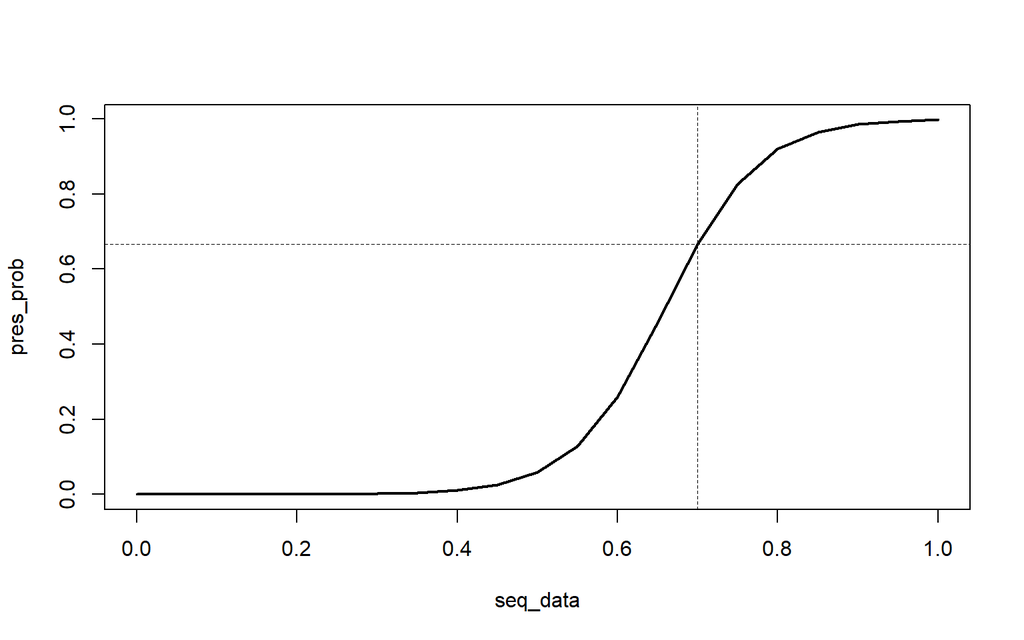

```r
abline(v=myvalue, lty=2,lwd=0.1)
abline(h=pres_prob_s, lty=2,lwd=0.1)
```

# END